# FastQ exercises

Rockefeller University, Bioinformatics Resource Centre

https://rockefelleruniversity.github.io/Bioconductor_Introduction/

These exercises cover the FastQ sections of [Introduction to Bioconductor](https://rockefelleruniversity.github.io/Bioconductor_Introduction/).

## Installing Bioconductor packages

In these exercises we will review some of the **ShortRead** packages functionality with handling fastQ files.

The example data can be found in the data directory

**data/sampled_ENCFF000CXH.fastq.gz**

We will also use the full FastQ file from this dataset which you can download from [here.](https://www.encodeproject.org/files/ENCFF000CXH/@@download/ENCFF000CXH.fastq.gz).

[output not shown]

[output not shown]

2. Plot the occurrence of A, G, T, C and N in the read with ID **“HWI-BRUNOP16X_0001:7:66:3246:157000#0/1”** using ggplot2

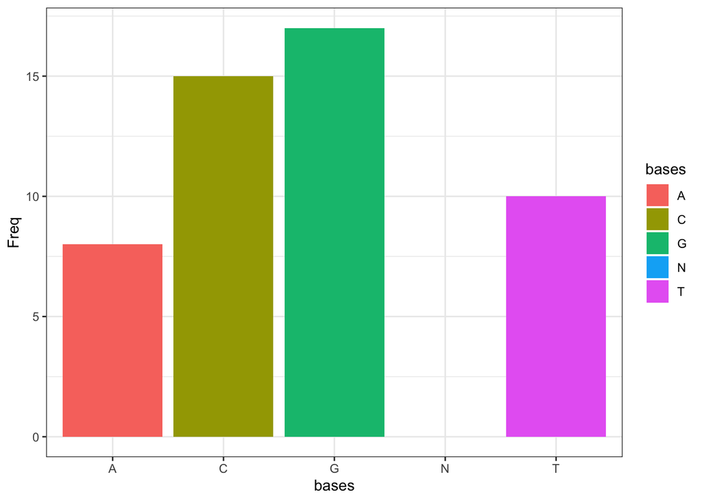

3. Create a boxplot of quality scores over cycles for reads using base graphics.

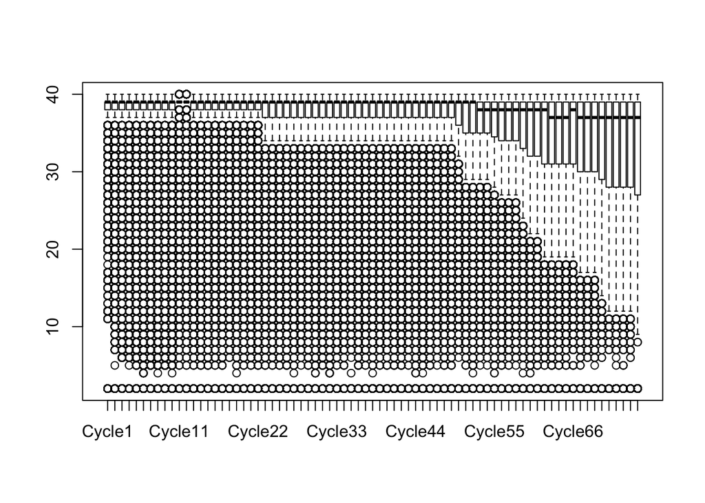

4. Plot the frequency of A, G, C, T and N bases over cycles using ggplot2/

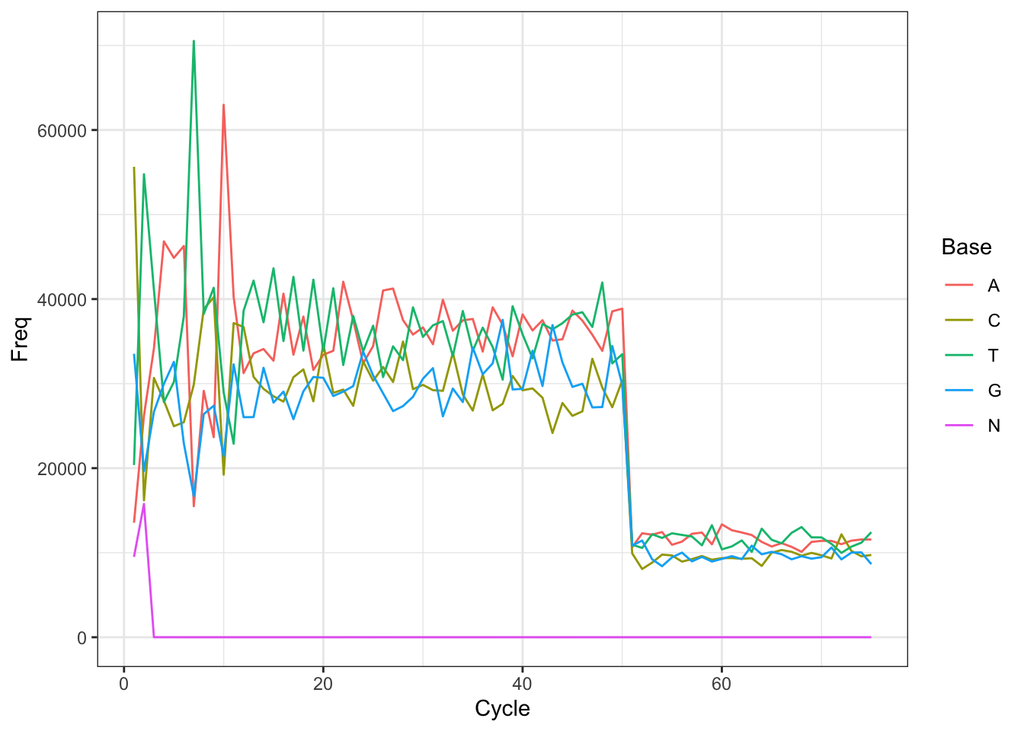

5. Read in a random 10000 bases from the downloaded **ENCFF000CXH.fastq.gz** file
6. Count the number of duplicate sequences and filter file to only the non-duplicated sequences
7. Trim the resulting non-duplicated reads to remove reads when a succession of 10 bases fall below quality of 5.
8. Plot a histogram of the resulting read lengths using base graphics

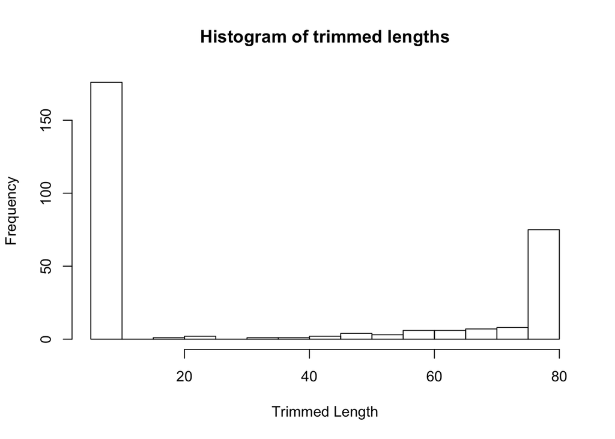

9.Filter out reads less than 32 bases and write to file